# Pneumonia Detection using CNN and Object Detection

## Capstone project

This notebook Goal is to look at given set of chest X-Ray images and create a model to classify whether a patient have Lung Opacity or not. If there is a lung opacity, provide marking. There is a third class "No lung opacity/Not normal" which is nothing but there is no peunomonia but the lung doesnot look normal too. We can optionally have marking for the third class.

### We have three milesone

#### Milestone 1:

Create a model to do classification of given patient dicom(xray) images to either they have Pneumonia or normal or no pneumonia/not normal.

#### Milestone 2:

Fine tune model, Apply Transfer learning and Perform object detection

#### Milestone 3:

Deploy model with UI

# ------------------------------ Milestone 1 ------------------------------

```python
%matplotlib inline

import math as math
import os
import pandas as pd
import numpy as np
import seaborn as sns
import matplotlib.pyplot as plt
from zipfile import ZipFile
```

# Step - 1. Import the data

```python
# GLobal and Milestone - 1 Variable
zip_directory='/tmp'
BATCH_SIZE = 32
```

```python
#from google.colab import drive
#drive.mount('/content/drive/')
#mainZipFile = ZipFile("drive/My Drive/Colab Notebooks/CV capstone-20230330T235201Z-002.zip", 'r')
#mainZipFile.extractall(zip_directory)
#mainZipFile.close()
```

```python
# The zip file is input we have got this project from Greatlearning
# It must be available to start and run remaining scripts in this project
mainZipFile = ZipFile("CV capstone-20230330T235201Z-002.zip")
mainZipFile.extractall(zip_directory)
```

### Step - 1.1. List all files inside zip

```python
mainZipFile.filelist
```

```
[<ZipInfo filename='CV capstone/' external_attr=0x11>,
 <ZipInfo filename='CV capstone/GCP Credits Request Link - RSNA.txt' compress_type=deflate external_attr=0x20 file_size=55 compress_size=57>,
 <ZipInfo filename='CV capstone/stage_2_detailed_class_info.csv' compress_type=deflate external_attr=0x20 file_size=1647396 compress_size=591502>,
 <ZipInfo filename='CV capstone/stage_2_sample_submission.csv' compress_type=deflate external_attr=0x20 file_size=159027 compress_size=64384>,
 <ZipInfo filename='CV capstone/stage_2_test_images.zip' external_attr=0x20 file_size=397164167>,
 <ZipInfo filename='CV capstone/stage_2_train_images.zip' external_attr=0x20 file_size=3534067864>,
 <ZipInfo filename='CV capstone/stage_2_train_labels.csv' compress_type=deflate external_attr=0x20 file_size=1490034 compress_size=671428>]
```

###### We have three csv and zip file

###### We have another Link file which we can ignore as it is having only credit information

### Step - 1.2: Read all csv files and check content

```python
class_info_df = pd.read_csv("CV capstone/stage_2_detailed_class_info.csv")
class_info_df
```

|  | patientId | class |
| --- | --- | --- |
| 0 | 0004cfab-14fd-4e49-80ba-63a80b6bddd6 | No Lung Opacity / Not Normal |
| 1 | 00313ee0-9eaa-42f4-b0ab-c148ed3241cd | No Lung Opacity / Not Normal |
| 2 | 00322d4d-1c29-4943-afc9-b6754be640eb | No Lung Opacity / Not Normal |
| 3 | 003d8fa0-6bf1-40ed-b54c-ac657f8495c5 | Normal |
| 4 | 00436515-870c-4b36-a041-de91049b9ab4 | Lung Opacity |
| ... | ... | ... |
| 30222 | c1ec14ff-f6d7-4b38-b0cb-fe07041cbdc8 | Lung Opacity |
| 30223 | c1edf42b-5958-47ff-a1e7-4f23d99583ba | Normal |
| 30224 | c1f6b555-2eb1-4231-98f6-50a963976431 | Normal |
| 30225 | c1f7889a-9ea9-4acb-b64c-b737c929599a | Lung Opacity |
| 30226 | c1f7889a-9ea9-4acb-b64c-b737c929599a | Lung Opacity |

30227 rows × 2 columns

```python
sample_submission_df = pd.read_csv("CV capstone/stage_2_sample_submission.csv")
sample_submission_df
```

|  | patientId | PredictionString |
| --- | --- | --- |
| 0 | 0000a175-0e68-4ca4-b1af-167204a7e0bc | 0.5 0 0 100 100 |
| 1 | 0005d3cc-3c3f-40b9-93c3-46231c3eb813 | 0.5 0 0 100 100 |
| 2 | 000686d7-f4fc-448d-97a0-44fa9c5d3aa6 | 0.5 0 0 100 100 |
| 3 | 000e3a7d-c0ca-4349-bb26-5af2d8993c3d | 0.5 0 0 100 100 |
| 4 | 00100a24-854d-423d-a092-edcf6179e061 | 0.5 0 0 100 100 |
| ... | ... | ... |
| 2995 | c1e88810-9e4e-4f39-9306-8d314bfc1ff1 | 0.5 0 0 100 100 |
| 2996 | c1ec035b-377b-416c-a281-f868b7c9b6c3 | 0.5 0 0 100 100 |
| 2997 | c1ef5b66-0fd7-49d1-ae6b-5af84929414b | 0.5 0 0 100 100 |
| 2998 | c1ef6724-f95f-40f1-b25b-de806d9bc39d | 0.5 0 0 100 100 |
| 2999 | c1f55e7e-4065-4dc0-993e-a7c1704c6036 | 0.5 0 0 100 100 |

3000 rows × 2 columns

###### The submission CSV file will be useful to verify the result of model and come up with accuracy measurement.

```python
train_label_df = pd.read_csv("CV capstone/stage_2_train_labels.csv")
train_label_df
```

|  | patientId | x | y | width | height | Target |
| --- | --- | --- | --- | --- | --- | --- |
| 0 | 0004cfab-14fd-4e49-80ba-63a80b6bddd6 | NaN | NaN | NaN | NaN | 0 |
| 1 | 00313ee0-9eaa-42f4-b0ab-c148ed3241cd | NaN | NaN | NaN | NaN | 0 |
| 2 | 00322d4d-1c29-4943-afc9-b6754be640eb | NaN | NaN | NaN | NaN | 0 |
| 3 | 003d8fa0-6bf1-40ed-b54c-ac657f8495c5 | NaN | NaN | NaN | NaN | 0 |
| 4 | 00436515-870c-4b36-a041-de91049b9ab4 | 264.0 | 152.0 | 213.0 | 379.0 | 1 |
| ... | ... | ... | ... | ... | ... | ... |
| 30222 | c1ec14ff-f6d7-4b38-b0cb-fe07041cbdc8 | 185.0 | 298.0 | 228.0 | 379.0 | 1 |
| 30223 | c1edf42b-5958-47ff-a1e7-4f23d99583ba | NaN | NaN | NaN | NaN | 0 |
| 30224 | c1f6b555-2eb1-4231-98f6-50a963976431 | NaN | NaN | NaN | NaN | 0 |
| 30225 | c1f7889a-9ea9-4acb-b64c-b737c929599a | 570.0 | 393.0 | 261.0 | 345.0 | 1 |
| 30226 | c1f7889a-9ea9-4acb-b64c-b737c929599a | 233.0 | 424.0 | 201.0 | 356.0 | 1 |

30227 rows × 6 columns

###### The lable file has patientid and coordinates

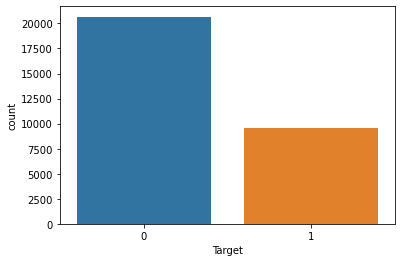

```python
sns.countplot(x=train_label_df['Target'])
```

```python
#sns.countplot(x=class_info_df['class'])
```

### Step - 1.3: We have training images in zip file.

```python
training_image_zip_file="CV capstone/stage_2_train_images.zip"
trainImgZipFile = ZipFile(training_image_zip_file, 'r')
trainImgZipFile.extractall(zip_directory + "/train_images")
trainImgZipFile.close()
trainImgZipFile.filelist
```

[output not shown]

[output cut: 946 more lines]

[output not shown]

### Step 1.4: Let us look at few images

```python
# We have dicom images and hence we need pydicom
!pip install pydicom
```

```python
# Print few images with its class
import random
import pydicom as dicom
```

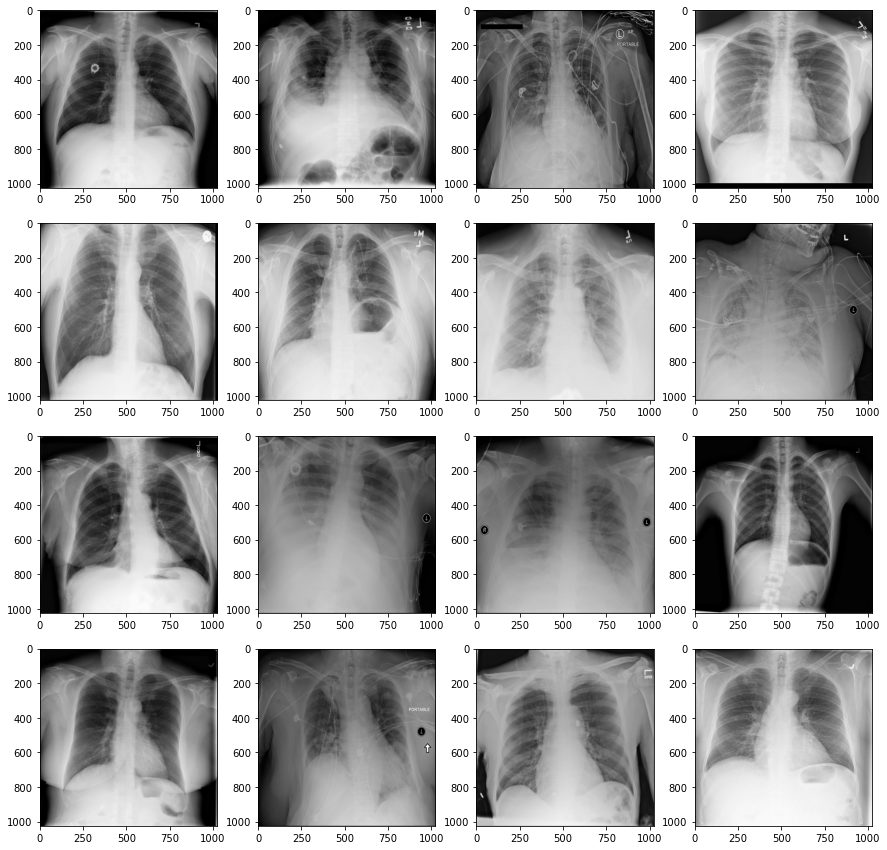

```python
fig = plt.figure(figsize=(15, 15))
N=16
for i in range(1, N+1):
    random_file=random.choice(os.listdir(zip_directory + "/train_images/stage_2_train_images"))
    fig.add_subplot(4, 4, i)
    dicom_image = dicom.dcmread(zip_directory + "/train_images/stage_2_train_images/" + random_file)
    plt.imshow(dicom_image.pixel_array, cmap=plt.cm.gray)
plt.show()
```

## Step - 2 & 3. Map training and testing images to its classes and Annotations

### Step 2.1 Iterate over image directory, resize images to 32 * 32 and normalize the image array. Also store the original image size in a dataframe

```python
!pip install tensorflow_io
```

```python
import os
import pydicom as dicom
import skimage.transform as st
import tensorflow as tf
import tensorflow_io as tfio

image_directory = zip_directory + "/train_images/stage_2_train_images"
total_number_of_files = 0
image_df = pd.DataFrame(columns=['image_file_name', 'path', 'actual_image', 'height', 'width'])
# Iterate directory
i = 0
for file in os.listdir(image_directory):
    # check if current path is a file
    if os.path.isfile(os.path.join(image_directory, file)):
        total_number_of_files += 1
        dicom_image = dicom.dcmread(os.path.join(image_directory, file))
        image_df.loc[i, 'path'] = os.path.join(image_directory, file)
        image_df.loc[i, 'image_file_name'] = file
        image_df.loc[i, 'actual_image'] = np.array((st.resize(dicom_image.pixel_array, (32, 32), anti_aliasing=True))/255)
        image_df.loc[i, 'height'] = dicom_image.Columns
        image_df.loc[i, 'width'] = dicom_image.Rows
        i+=1
print(f"We have {total_number_of_files} total number of image files");
```

```
We have 26684 total number of image files
```

```python
image_df
```

|  | image_file_name | path | actual_image | height | width |
| --- | --- | --- | --- | --- | --- |
| 0 | 0004cfab-14fd-4e49-80ba-63a80b6bddd6.dcm | /tmp/train_images/stage_2_train_images\0004cfa... | [[8.286463581287197e-05, 4.041750331910769e-05... | 1024 | 1024 |
| 1 | 000924cf-0f8d-42bd-9158-1af53881a557.dcm | /tmp/train_images/stage_2_train_images\000924c... | [[7.194814904496719e-05, 0.0002037581145740258... | 1024 | 1024 |
| 2 | 000db696-cf54-4385-b10b-6b16fbb3f985.dcm | /tmp/train_images/stage_2_train_images\000db69... | [[4.487527018563684e-05, 4.5375053597157953e-0... | 1024 | 1024 |
| 3 | 000fe35a-2649-43d4-b027-e67796d412e0.dcm | /tmp/train_images/stage_2_train_images\000fe35... | [[0.0002417167778605627, 0.0002527935192363741... | 1024 | 1024 |
| 4 | 001031d9-f904-4a23-b3e5-2c088acd19c6.dcm | /tmp/train_images/stage_2_train_images\001031d... | [[6.772987099858779e-05, 0.0003000979514369435... | 1024 | 1024 |
| ... | ... | ... | ... | ... | ... |
| 26679 | fffb2395-8edd-4954-8a89-ffe2fd329be3.dcm | /tmp/train_images/stage_2_train_images\fffb239... | [[7.163705612606939e-05, 6.700455796513645e-05... | 1024 | 1024 |
| 26680 | fffba05a-1635-4545-9bbd-57ad4cfe8d27.dcm | /tmp/train_images/stage_2_train_images\fffba05... | [[4.6134528863375316e-05, 4.610083468755934e-0... | 1024 | 1024 |
| 26681 | fffc95b5-605b-4226-80ab-62caec682b22.dcm | /tmp/train_images/stage_2_train_images\fffc95b... | [[0.0003491565798057978, 0.000770259978522427,... | 1024 | 1024 |
| 26682 | fffcff11-d018-4414-971a-a7cefa327795.dcm | /tmp/train_images/stage_2_train_images\fffcff1... | [[1.344063738425597e-05, 4.654971683902636e-07... | 1024 | 1024 |
| 26683 | fffec09e-8a4a-48b1-b33e-ab4890ccd136.dcm | /tmp/train_images/stage_2_train_images\fffec09... | [[0.00026488671541695987, 0.000284427266758785... | 1024 | 1024 |

26684 rows × 5 columns

## Step - 2.2 The image_file_name has both extension and patienid. Split and store it.

```python
image_df[['patientId', 'extension']] = image_df['image_file_name'].str.split('.', 1, expand=True)
```

```python
image_df.shape
```

```
(26684, 7)
```

```python
# Check if we have duplicates. We have seen trining label was having 30227 records which means
# we have duplicate in the label CSV hence remove it
image_df[image_df.duplicated('patientId') == True]
```

|  | image_file_name | path | actual_image | height | width | patientId | extension |
| --- | --- | --- | --- | --- | --- | --- | --- |

## Step 2.3 Train label CSV sounds like having some duplicate - remove it.

```python
train_label_df = train_label_df[train_label_df.duplicated('patientId') == False]
```

```python
train_label_df.shape
```

```
(26684, 6)
```

###### Now, we have three dataframe. The image_df have all images loaded with its attributes, we have train_label_df having all coordinates and we also have class_info_df with classification label for images. The common id between all three dataframe is 'pateientid' which we can use for mering them.

### Step - 3.1: Merge classes and Annotation dataframe with image

```python
data = image_df.merge(train_label_df, on="patientId")
```

```python
data.shape
```

```
(26684, 12)
```

```python
class_info_df = class_info_df[class_info_df.duplicated('patientId') == False]
```

```python
data = data.merge(class_info_df, on="patientId")
```

```python
first_column = data.pop('patientId')
data.insert(0, 'patientId', first_column)
```

```python
data
```

|  | patientId | image_file_name | path | actual_image | height_x | width_x | extension | x | y | width_y | height_y | Target | class |
| --- | --- | --- | --- | --- | --- | --- | --- | --- | --- | --- | --- | --- | --- |
| 0 | 0004cfab-14fd-4e49-80ba-63a80b6bddd6 | 0004cfab-14fd-4e49-80ba-63a80b6bddd6.dcm | /tmp/train_images/stage_2_train_images\0004cfa... | [[8.286463581287197e-05, 4.041750331910769e-05... | 1024 | 1024 | dcm | NaN | NaN | NaN | NaN | 0 | No Lung Opacity / Not Normal |
| 1 | 000924cf-0f8d-42bd-9158-1af53881a557 | 000924cf-0f8d-42bd-9158-1af53881a557.dcm | /tmp/train_images/stage_2_train_images\000924c... | [[7.194814904496719e-05, 0.0002037581145740258... | 1024 | 1024 | dcm | NaN | NaN | NaN | NaN | 0 | Normal |
| 2 | 000db696-cf54-4385-b10b-6b16fbb3f985 | 000db696-cf54-4385-b10b-6b16fbb3f985.dcm | /tmp/train_images/stage_2_train_images\000db69... | [[4.487527018563684e-05, 4.5375053597157953e-0... | 1024 | 1024 | dcm | 316.0 | 318.0 | 170.0 | 478.0 | 1 | Lung Opacity |
| 3 | 000fe35a-2649-43d4-b027-e67796d412e0 | 000fe35a-2649-43d4-b027-e67796d412e0.dcm | /tmp/train_images/stage_2_train_images\000fe35... | [[0.0002417167778605627, 0.0002527935192363741... | 1024 | 1024 | dcm | 570.0 | 282.0 | 269.0 | 409.0 | 1 | Lung Opacity |
| 4 | 001031d9-f904-4a23-b3e5-2c088acd19c6 | 001031d9-f904-4a23-b3e5-2c088acd19c6.dcm | /tmp/train_images/stage_2_train_images\001031d... | [[6.772987099858779e-05, 0.0003000979514369435... | 1024 | 1024 | dcm | 66.0 | 160.0 | 373.0 | 608.0 | 1 | Lung Opacity |
| ... | ... | ... | ... | ... | ... | ... | ... | ... | ... | ... | ... | ... | ... |
| 26679 | fffb2395-8edd-4954-8a89-ffe2fd329be3 | fffb2395-8edd-4954-8a89-ffe2fd329be3.dcm | /tmp/train_images/stage_2_train_images\fffb239... | [[7.163705612606939e-05, 6.700455796513645e-05... | 1024 | 1024 | dcm | 177.0 | 285.0 | 225.0 | 529.0 | 1 | Lung Opacity |
| 26680 | fffba05a-1635-4545-9bbd-57ad4cfe8d27 | fffba05a-1635-4545-9bbd-57ad4cfe8d27.dcm | /tmp/train_images/stage_2_train_images\fffba05... | [[4.6134528863375316e-05, 4.610083468755934e-0... | 1024 | 1024 | dcm | NaN | NaN | NaN | NaN | 0 | Normal |
| 26681 | fffc95b5-605b-4226-80ab-62caec682b22 | fffc95b5-605b-4226-80ab-62caec682b22.dcm | /tmp/train_images/stage_2_train_images\fffc95b... | [[0.0003491565798057978, 0.000770259978522427,... | 1024 | 1024 | dcm | NaN | NaN | NaN | NaN | 0 | No Lung Opacity / Not Normal |
| 26682 | fffcff11-d018-4414-971a-a7cefa327795 | fffcff11-d018-4414-971a-a7cefa327795.dcm | /tmp/train_images/stage_2_train_images\fffcff1... | [[1.344063738425597e-05, 4.654971683902636e-07... | 1024 | 1024 | dcm | NaN | NaN | NaN | NaN | 0 | No Lung Opacity / Not Normal |
| 26683 | fffec09e-8a4a-48b1-b33e-ab4890ccd136 | fffec09e-8a4a-48b1-b33e-ab4890ccd136.dcm | /tmp/train_images/stage_2_train_images\fffec09... | [[0.00026488671541695987, 0.000284427266758785... | 1024 | 1024 | dcm | NaN | NaN | NaN | NaN | 0 | No Lung Opacity / Not Normal |

26684 rows × 13 columns

# Step - 4: Preprocessing and Visualisation of different classes

## Step - 4.1 Print random images from merged dataframe along with its class

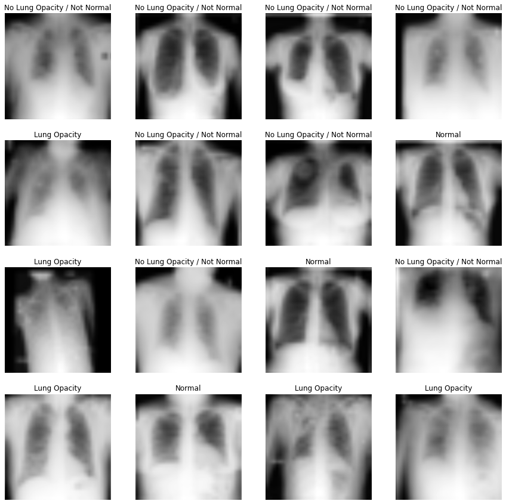

```python
# Print few images with its class
import random
import pydicom as dicom

fig = plt.figure(figsize=(15, 15))
N=16
for i in range(1, N+1):
    loc = random.randint(1, total_number_of_files)
    #random_file=random.choice(os.listdir(zip_directory + "/train_images/stage_2_train_images"))
    #print(random_file)
    fig.add_subplot(4, 4, i)
    #dicom_image = dicom.dcmread(data.loc[loc, 'actual_image'])
    plt.imshow(st.resize(data.loc[loc, 'actual_image'],  (1024, 1024)),  cmap=plt.cm.gray)
    plt.title(data.loc[loc, 'class'])
    plt.axis('off')
plt.show()
```

##### We have lost the image quality after we have created dataframe with image array after resizing.

## Step - 4.2 Check the "Class" balance

```python
#sns.countplot(x=data["class"])
```

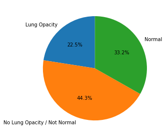

```python
unique_values, count = np.unique(data['class'], return_counts=True)
plt.pie(count, labels = ['Lung Opacity', 'No Lung Opacity / Not Normal', 'Normal'], autopct='%1.1f%%', startangle=90)
plt.tight_layout()
```

###### Class is not balanced. We should do something about it. The easiest theings to do is to downsampling which will still give good population of data (~18K). But for correct things to do for CNN is to do Image Augumentation which we will try in MIlestone - 2

## Step - 4.3: Let us encode class variable

```python
from sklearn import preprocessing

# label_encoder object knows how to understand word labels.
label_encoder = preprocessing.LabelEncoder()

# Encode labels in column 'class'.
data['class_no']= label_encoder.fit_transform(data['class'])
df = data.drop(labels='class', axis=1)
df
```

|  | patientId | image_file_name | path | actual_image | height_x | width_x | extension | x | y | width_y | height_y | Target | class_no |
| --- | --- | --- | --- | --- | --- | --- | --- | --- | --- | --- | --- | --- | --- |
| 0 | 0004cfab-14fd-4e49-80ba-63a80b6bddd6 | 0004cfab-14fd-4e49-80ba-63a80b6bddd6.dcm | /tmp/train_images/stage_2_train_images\0004cfa... | [[8.286463581287197e-05, 4.041750331910769e-05... | 1024 | 1024 | dcm | NaN | NaN | NaN | NaN | 0 | 1 |
| 1 | 000924cf-0f8d-42bd-9158-1af53881a557 | 000924cf-0f8d-42bd-9158-1af53881a557.dcm | /tmp/train_images/stage_2_train_images\000924c... | [[7.194814904496719e-05, 0.0002037581145740258... | 1024 | 1024 | dcm | NaN | NaN | NaN | NaN | 0 | 2 |
| 2 | 000db696-cf54-4385-b10b-6b16fbb3f985 | 000db696-cf54-4385-b10b-6b16fbb3f985.dcm | /tmp/train_images/stage_2_train_images\000db69... | [[4.487527018563684e-05, 4.5375053597157953e-0... | 1024 | 1024 | dcm | 316.0 | 318.0 | 170.0 | 478.0 | 1 | 0 |
| 3 | 000fe35a-2649-43d4-b027-e67796d412e0 | 000fe35a-2649-43d4-b027-e67796d412e0.dcm | /tmp/train_images/stage_2_train_images\000fe35... | [[0.0002417167778605627, 0.0002527935192363741... | 1024 | 1024 | dcm | 570.0 | 282.0 | 269.0 | 409.0 | 1 | 0 |
| 4 | 001031d9-f904-4a23-b3e5-2c088acd19c6 | 001031d9-f904-4a23-b3e5-2c088acd19c6.dcm | /tmp/train_images/stage_2_train_images\001031d... | [[6.772987099858779e-05, 0.0003000979514369435... | 1024 | 1024 | dcm | 66.0 | 160.0 | 373.0 | 608.0 | 1 | 0 |
| ... | ... | ... | ... | ... | ... | ... | ... | ... | ... | ... | ... | ... | ... |
| 26679 | fffb2395-8edd-4954-8a89-ffe2fd329be3 | fffb2395-8edd-4954-8a89-ffe2fd329be3.dcm | /tmp/train_images/stage_2_train_images\fffb239... | [[7.163705612606939e-05, 6.700455796513645e-05... | 1024 | 1024 | dcm | 177.0 | 285.0 | 225.0 | 529.0 | 1 | 0 |
| 26680 | fffba05a-1635-4545-9bbd-57ad4cfe8d27 | fffba05a-1635-4545-9bbd-57ad4cfe8d27.dcm | /tmp/train_images/stage_2_train_images\fffba05... | [[4.6134528863375316e-05, 4.610083468755934e-0... | 1024 | 1024 | dcm | NaN | NaN | NaN | NaN | 0 | 2 |
| 26681 | fffc95b5-605b-4226-80ab-62caec682b22 | fffc95b5-605b-4226-80ab-62caec682b22.dcm | /tmp/train_images/stage_2_train_images\fffc95b... | [[0.0003491565798057978, 0.000770259978522427,... | 1024 | 1024 | dcm | NaN | NaN | NaN | NaN | 0 | 1 |
| 26682 | fffcff11-d018-4414-971a-a7cefa327795 | fffcff11-d018-4414-971a-a7cefa327795.dcm | /tmp/train_images/stage_2_train_images\fffcff1... | [[1.344063738425597e-05, 4.654971683902636e-07... | 1024 | 1024 | dcm | NaN | NaN | NaN | NaN | 0 | 1 |
| 26683 | fffec09e-8a4a-48b1-b33e-ab4890ccd136 | fffec09e-8a4a-48b1-b33e-ab4890ccd136.dcm | /tmp/train_images/stage_2_train_images\fffec09... | [[0.00026488671541695987, 0.000284427266758785... | 1024 | 1024 | dcm | NaN | NaN | NaN | NaN | 0 | 1 |

26684 rows × 13 columns

```python
df[df.duplicated('patientId') == True]
```

|  | patientId | image_file_name | path | actual_image | height_x | width_x | extension | x | y | width_y | height_y | Target | class_no |
| --- | --- | --- | --- | --- | --- | --- | --- | --- | --- | --- | --- | --- | --- |

## Step - 4.4: EDA and Plots

```python
df.info()
```

```
<class 'pandas.core.frame.DataFrame'>
Int64Index: 26684 entries, 0 to 26683
Data columns (total 13 columns):
 #   Column           Non-Null Count  Dtype
---  ------           --------------  -----
 0   patientId        26684 non-null  object
 1   image_file_name  26684 non-null  object
 2   path             26684 non-null  object
 3   actual_image     26684 non-null  object
 4   height_x         26684 non-null  object
 5   width_x          26684 non-null  object
 6   extension        26684 non-null  object
 7   x                6012 non-null   float64
 8   y                6012 non-null   float64
 9   width_y          6012 non-null   float64
 10  height_y         6012 non-null   float64
 11  Target           26684 non-null  int64
 12  class_no         26684 non-null  int32
dtypes: float64(4), int32(1), int64(1), object(7)
memory usage: 3.8+ MB
```

```python
df.isna().sum()
```

```
patientId              0
image_file_name        0
path                   0
actual_image           0
height_x               0
width_x                0
extension              0
x                  20672
y                  20672
width_y            20672
height_y           20672
Target                 0
class_no               0
dtype: int64
```

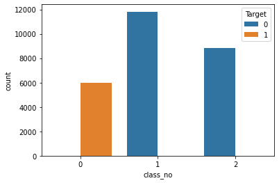

```python
sns.countplot(x='class_no',hue='Target',data=df)
```

###### Obviously we have missing coordinates. We have coordinates for approximately only for 6k records.

###### Countplot gives same data where only class - 0 has set to Target 1 and remaining classes are set to Target = 0. THis means we have Target representing available coordinates (annotations) or not

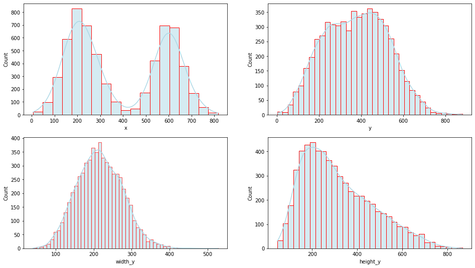

```python
column = ['x','y','width_y','height_y']

fig, axes = plt.subplots(ncols=2, nrows=2, figsize=(16,9))
for idx, ax in zip(column, axes.flat):
    sns.histplot(data=df, x=idx, kde=True, color = "lightblue", ec="red", ax=ax)
plt.show()
```

##### We have X 150 to 300, 550 to 700 having more number of reocrds. Similarly we have Y value 150 to 600 having more number of records. THe number of records are less than 50 in counts when the Y is beyond 60

##### Width_y is normally distributed and Height_Y is right skewed.

##### Overall we have average bounding box with some large boxes as well.

```python
#plt.figure(figsize=(17,10))
#sns.boxplot(data=df)
#plt.show()
```

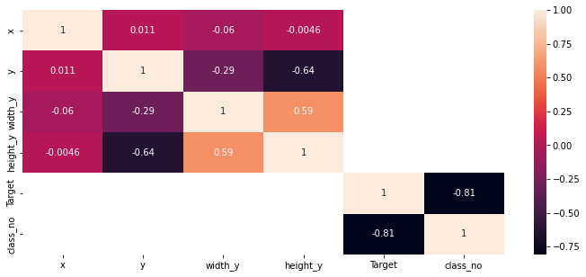

```python
corr = df.corr()
plt.figure(figsize=(12,5))

sns.heatmap(corr,annot=True)
```

##### We don't have much coorrelation between variables however average coorelation can be seen between Width_y vs Height_y and negative average coorrelation can be seen between Y and Height_y

# Step - 5: Display images with bounding box

## Step - 5.1: Display random images with bounding box

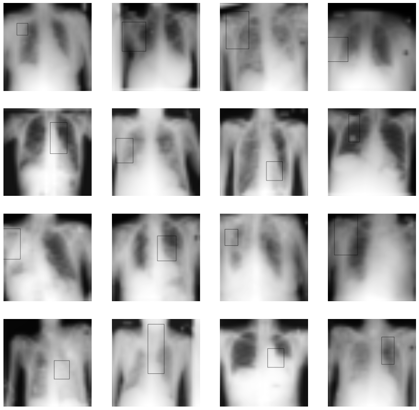

```python
import cv2
import random

fig = plt.figure(figsize=(15, 15))
N=16
i = 0
#temp_df = df.query("x != nan").sample(n=200)
temp_df = df.loc[df['x'].notnull()]
temp_df = temp_df.sample(100, ignore_index=True)
#print(temp_df)
for i in range(1, N+1):
    loc = random.randint(1, (len(temp_df) - 1))
    fig.add_subplot(4, 4, i)

    x0 = temp_df.loc[loc, 'x'] - temp_df.loc[loc, 'width_y'] / 2
    x1 = temp_df.loc[loc, 'x'] + temp_df.loc[loc, 'width_y'] / 2
    y0 = temp_df.loc[loc, 'y'] - temp_df.loc[loc, 'height_y'] / 2
    y1 = temp_df.loc[loc, 'y'] + temp_df.loc[loc, 'height_y'] / 2

    start_point = (int(x0), int(y0))
    end_point = (int(x1), int(y1))

    plt.imshow(cv2.rectangle(st.resize(temp_df.loc[loc, 'actual_image'],  (1024, 1024)), start_point,
                              end_point, color=(0,0,255), thickness=2), cmap=plt.cm.gray)
    plt.axis('off')
plt.show()
```

# Step - 6: Design, train and test basic CNN models for classification

## Step - 6.1: Split X & Y and get train and test

```python
X = df['actual_image']
Y = df['class_no']
```

```python
X
```

```
0        [[8.286463581287197e-05, 4.041750331910769e-05...
1        [[7.194814904496719e-05, 0.0002037581145740258...
2        [[4.487527018563684e-05, 4.5375053597157953e-0...
3        [[0.0002417167778605627, 0.0002527935192363741...
4        [[6.772987099858779e-05, 0.0003000979514369435...
                               ...
26679    [[7.163705612606939e-05, 6.700455796513645e-05...
26680    [[4.6134528863375316e-05, 4.610083468755934e-0...
26681    [[0.0003491565798057978, 0.000770259978522427,...
26682    [[1.344063738425597e-05, 4.654971683902636e-07...
26683    [[0.00026488671541695987, 0.000284427266758785...
Name: actual_image, Length: 26684, dtype: object
```

## Step - 6.1 Convert to tensor and start basic classification model

```python
# For validation of model result have test:train:validation split
# It will help understand model accuracy
from sklearn.model_selection import train_test_split

def train_test_val_split(X,Y):
    train_ratio = 0.75
    validation_ratio = 0.10
    test_ratio = 0.15

    x_train, x_test, y_train, y_test = train_test_split(X, Y, test_size=1 - train_ratio)
    x_val, x_test, y_val, y_test = train_test_split(x_test, y_test, test_size=test_ratio/(test_ratio + validation_ratio))
    print(f"{x_train.shape} is x_train shape, {x_test.shape} x_test shape, {x_val.shape} x_val shape, {y_train.shape} is y_train shape, {y_test.shape} y_test shape, {y_val.shape} y_val shape")
    return x_train, x_test, x_val, y_train, y_test, y_val
```

```python
import torch
import torchvision.transforms as transforms
import tensorflow as tf
```

```python
x_train, x_test, x_val, y_train, y_test, y_val = train_test_val_split(X, Y)
```

```
(20013,) is x_train shape, (4003,) x_test shape, (2668,) x_val shape, (20013,) is y_train shape, (4003,) y_test shape, (2668,) y_val shape
```

###### We have 75% data allocated for training, 15% for testing and 10% for validation.

```python
from skimage.color import gray2rgb

X_train = gray2rgb(x_train.to_list())
X_test = gray2rgb(x_test.to_list())
X_val = gray2rgb(x_val.to_list())
```

```python
print(f"{X_train.shape} is X_train shape, {X_test.shape} X_test shape, {X_val.shape} is X_val shape, {y_train.shape} is y_train shape, {y_test.shape} y_test shape, {y_val.shape} y_val shape")
```

```
(20013, 32, 32, 3) is X_train shape, (4003, 32, 32, 3) X_test shape, (2668, 32, 32, 3) is X_val shape, (20013,) is y_train shape, (4003,) y_test shape, (2668,) y_val shape
```

## Step - 6.3 Build basic CNN model with three convulution layer with sofmax for multi- classification

```python
from tensorflow.keras.models import Sequential
from tensorflow.keras.layers import InputLayer,Activation, Conv2D, Dropout, Dense, Flatten, BatchNormalization, MaxPool2D, GlobalMaxPool2D
from tensorflow.keras import optimizers
from tensorflow.keras.callbacks import EarlyStopping
```

```python
def get_model():
    model = Sequential()

    model.add(InputLayer(input_shape = (32,32,3,)))
    model.add(Conv2D(64, kernel_size=(3,3), activation='relu'))
    model.add(BatchNormalization())

    model.add(Conv2D(64, kernel_size=(3,3), activation='relu'))
    model.add(BatchNormalization())
    model.add(Conv2D(128, kernel_size=(3,3), activation='relu'))

    model.add(Dense(128, activation='relu'))
    model.add(Dense(64, activation='relu'))
    model.add(BatchNormalization())
    model.add(Flatten())

    model.add(Dense(3, activation='softmax'))
    return model
```

```python
model = get_model()
model.compile(optimizer='SGD', loss = 'sparse_categorical_crossentropy', metrics = ['accuracy'])
model.summary()
```

```
Model: "sequential"
_________________________________________________________________
 Layer (type)                Output Shape              Param #
=================================================================
 conv2d (Conv2D)             (None, 30, 30, 64)        1792

 batch_normalization (BatchN  (None, 30, 30, 64)       256
 ormalization)

 conv2d_1 (Conv2D)           (None, 28, 28, 64)        36928

 batch_normalization_1 (Batc  (None, 28, 28, 64)       256
 hNormalization)

 conv2d_2 (Conv2D)           (None, 26, 26, 128)       73856

 dense (Dense)               (None, 26, 26, 128)       16512

 dense_1 (Dense)             (None, 26, 26, 64)        8256

 batch_normalization_2 (Batc  (None, 26, 26, 64)       256
 hNormalization)

 flatten (Flatten)           (None, 43264)             0

 dense_2 (Dense)             (None, 3)                 129795

=================================================================
Total params: 267,907
Trainable params: 267,523
Non-trainable params: 384
_________________________________________________________________
```

```python
earlyStoppingCallback = EarlyStopping(monitor='val_loss', patience=3)
history = model.fit(X_train, y_train, epochs = 20, batch_size=BATCH_SIZE,
                        validation_data=(X_test, y_test))#,  callbacks=[earlyStoppingCallback])
```

## Step - 6.4: Plot accuracy and loss

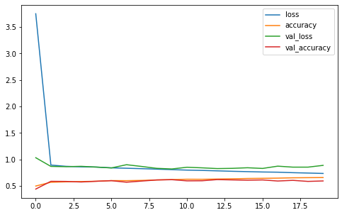

```python
pd.DataFrame(history.history).plot(figsize=(8,5))
plt.show()
```

##### The accuracy of training is showing small improvements and testing was little going up and down.

```python
from sklearn.metrics import classification_report
```

```python
y_val_prediction_model = model.predict(X_val)
y_val_prediction=[]
for i in y_val_prediction_model:
  y_val_prediction.append(np.argmax(i))

cr = classification_report(y_val,y_val_prediction)
print(cr)

#classification_report(label_encoder.inverse_transform(y_val),label_encoder.inverse_transform(y_val_prediction)
```

```
              precision    recall  f1-score   support

           0       0.62      0.33      0.43       605
           1       0.59      0.62      0.60      1247
           2       0.57      0.73      0.64       816

    accuracy                           0.59      2668
   macro avg       0.59      0.56      0.56      2668
weighted avg       0.59      0.59      0.57      2668
```

```python
from sklearn.metrics import confusion_matrix
```

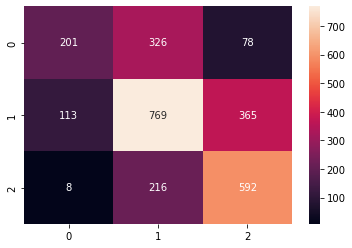

```python
confusion_mtx = confusion_matrix(y_val, y_val_prediction)
sns.heatmap(confusion_mtx, annot=True, fmt='d')
```

## Step - 6.5 Few images with actual VS predicted label

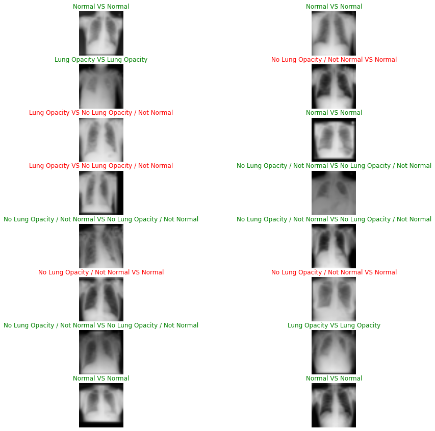

```python
fig = plt.figure(figsize=(15, 15))
N=16
for i in range(1, N+1):
    loc = random.randint(1, len(X_val))
    actual = label_encoder.inverse_transform(y_val)[loc]
    predicted = label_encoder.inverse_transform(y_val_prediction)[loc]
    if (actual == predicted):
        params = {"text.color" : "green"}
    else:
        params = {"text.color" : "red"}
    plt.rcParams.update(params)
    fig.add_subplot(8, 2, i)
    plt.imshow(st.resize(X_val[loc] * 255,  (1024, 1024)))
    plt.title(actual + ' VS ' + predicted)
    plt.axis('off')
plt.show()
```

# Step - 7: Interim Report

##### The interim report is created and submitted separately.

# ------------------------------ Milestone 2 ------------------------------

# Step 1: Fine tune the trained basic CNN models for classification

```python
from statistics import mean

# Evaluation result as dataframe. Useful later
eval_df = pd.DataFrame(columns=['model_name', 'loss', 'accuracy', 'description'])
```

## Step 1.1: Downsample dataset

```python
from sklearn.model_selection import train_test_split
from skimage.color import gray2rgb
from tensorflow.keras.callbacks import EarlyStopping
import skimage.transform as st
```

```python
threshold = 6012
df_0 = df.query('(class_no == 0)').sample(n=(threshold))
df_1 = df.query('(class_no == 1)').sample(n=(threshold))
df_2 = df.query('(class_no == 2)').sample(n=(threshold))

down_df = pd.concat([df_0.sample(frac=1), df_1.sample(frac=1), df_2.sample(frac=1)], ignore_index=True)
down_df.shape
```

```
(18036, 13)
```

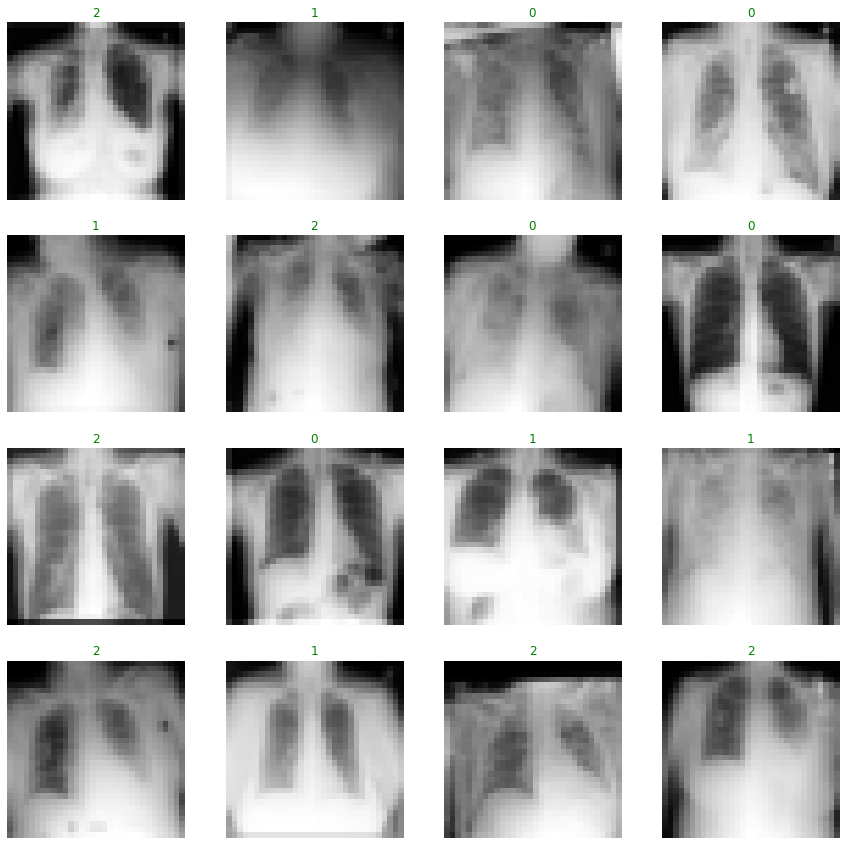

```python
# Print few images with its class
import random
import pydicom as dicom

fig = plt.figure(figsize=(15, 15))
N=16
total_number_of_files = len(down_df)
for i in range(1, N+1):
    loc = random.randint(1, total_number_of_files)
    fig.add_subplot(4, 4, i)
   # print(np.array(down_df.loc[loc, 'actual_image']))
    plt.imshow(st.resize(np.array(down_df.loc[loc, 'actual_image']),  (32, 32)),  cmap=plt.cm.gray)
    plt.title(data.loc[loc, 'class_no'])
    plt.axis('off')
plt.show()
```

```python
down_X = down_df['actual_image']
down_Y = down_df['class_no']
```

```python
#down_x_train, down_x_test, down_x_val, down_y_train, down_y_test, down_y_val = train_test_val_split(down_X, down_Y)
down_x_train, down_x_test, down_y_train, down_y_test = train_test_split(down_X, down_Y)
```

```python
down_X_train = gray2rgb(down_x_train.to_list())
down_X_test = gray2rgb(down_x_test.to_list())
#down_X_val = gray2rgb(down_x_val.to_list())
print(f"{down_X_train.shape} is down_X_train shape, {down_X_test.shape} down_X_test shape")
```

```
(13527, 32, 32, 3) is down_X_train shape, (4509, 32, 32, 3) down_X_test shape
```

```python
# Quickly check whether our existing model is providing any
# improvements with downsampling. We will use earlystopping callback to asses whether
# we should take this route or not
earlyStoppingCallback = EarlyStopping(monitor='val_loss', patience=5)
down_history = model.fit(down_X_train, down_y_train, epochs = 25, batch_size=BATCH_SIZE,
                        validation_data=(down_X_test, down_y_test), callbacks=[earlyStoppingCallback])
```

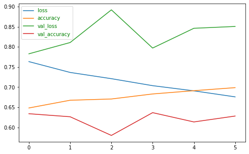

```python
pd.DataFrame(down_history.history).plot(figsize=(8,5))
plt.show()
```

##### With downsampled data - we are seeing similar trend. Accuracy is not improving.

## Step 1.2: Tunning Model for more accuracy

```python
#model2 = model.layers[-3].output
model2 = Sequential()
model2.add(InputLayer(input_shape = (32,32,3,)))
for layer in model.layers[:-3]:
    model2.add(layer)
model2.add(Conv2D(256, kernel_size=(3,3), activation='relu'))
model2.add(Dropout(0.2))
model2.add(BatchNormalization())
model2.add(Conv2D(128, kernel_size=(3,3), activation='relu'))
model2.add(BatchNormalization())
model2.add(Dropout(0.2))
model2.add(Conv2D(64, kernel_size=(3,3), activation='relu'))
model2.add(BatchNormalization())
model2.add(Dropout(0.2))
model2.add(Conv2D(32, kernel_size=(3,3), activation='relu'))
model2.add(BatchNormalization())
model2.add(Flatten())
model2.add(Dense(3, activation='softmax'))
model2.build()
model2.summary()
```

```
Model: "sequential_1"
_________________________________________________________________
 Layer (type)                Output Shape              Param #
=================================================================
 conv2d (Conv2D)             (None, 30, 30, 64)        1792

 batch_normalization (BatchN  (None, 30, 30, 64)       256
 ormalization)

 conv2d_1 (Conv2D)           (None, 28, 28, 64)        36928

 batch_normalization_1 (Batc  (None, 28, 28, 64)       256
 hNormalization)

 conv2d_2 (Conv2D)           (None, 26, 26, 128)       73856

 dense (Dense)               (None, 26, 26, 128)       16512

 dense_1 (Dense)             (None, 26, 26, 64)        8256

 conv2d_3 (Conv2D)           (None, 24, 24, 256)       147712

 dropout (Dropout)           (None, 24, 24, 256)       0

 batch_normalization_3 (Batc  (None, 24, 24, 256)      1024
 hNormalization)

 conv2d_4 (Conv2D)           (None, 22, 22, 128)       295040

 batch_normalization_4 (Batc  (None, 22, 22, 128)      512
 hNormalization)

 dropout_1 (Dropout)         (None, 22, 22, 128)       0

 conv2d_5 (Conv2D)           (None, 20, 20, 64)        73792

 batch_normalization_5 (Batc  (None, 20, 20, 64)       256
 hNormalization)

 dropout_2 (Dropout)         (None, 20, 20, 64)        0

 conv2d_6 (Conv2D)           (None, 18, 18, 32)        18464

 batch_normalization_6 (Batc  (None, 18, 18, 32)       128
 hNormalization)

 flatten_1 (Flatten)         (None, 10368)             0

 dense_3 (Dense)             (None, 3)                 31107

=================================================================
Total params: 705,891
Trainable params: 704,675
Non-trainable params: 1,216
_________________________________________________________________
```

```python
model2.compile(optimizer='SGD', loss = 'sparse_categorical_crossentropy', metrics = ['accuracy'])
```

```python
model2_history = model2.fit(X_train, y_train, epochs = 20, batch_size=BATCH_SIZE,
                        validation_data=(X_test, y_test))
```

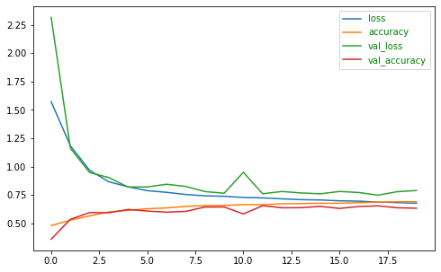

```python
pd.DataFrame(model2_history.history).plot(figsize=(8,5))
plt.show()
```

```python
model1_eval_result = model.evaluate(X_test,y_test, verbose=0)  # From milestone-1
```

```python
eval_df.loc[len(eval_df.index)] = ['model_1', model1_eval_result[0], model1_eval_result[1], "Basic CNN with 3 hidden layer without dropout"]
```

```python
model2_eval_result = model2.evaluate(X_test, y_test, verbose=0) # With more hidden layers
```

```python
eval_df.loc[len(eval_df.index)] = ['model_2', model2_eval_result[0], model2_eval_result[1], "Basic CNN with 7 hidden layer, dropout"]
```

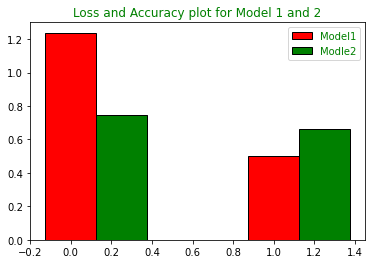

```python
#plt.plot( model1_eval_result,'green', model2_eval_result, 'red', )
r = np.arange(2)
width = 0.25
bar1 = plt.bar(r, model1_eval_result, color = 'r',
        width = width, edgecolor = 'black',
        label='Model1')
bar2 = plt.bar(r + width, model2_eval_result, color = 'g',
        width = width, edgecolor = 'black',
        label='Modle2')

plt.legend()
plt.title("Loss and Accuracy plot for Model 1 and 2")
plt.show()
```

##### Testing accuracy is 66% which is higher with the addition of 4 more hidden layers in Model 2

##### Let us try to find Best Learning Rate and Momentum

```python
# Following code was running more hours and it pretend to be in hung state.
# The TQDM package can help display progress bar indicator
!pip install tqdm
from tqdm import tqdm
```

```python
# Few reference material studied for this. The Grid Search Model is something not suitable for PC/laptop environment as
# it tends to take lot of time which puts the system in high utilization. The summar time adds up to the heat and power cut
# which makes the system shutdown while running. The best place to run all these is Cloud. Followinv code was written
# kept all these bad experience in mind. Hence the early stopping callback was set ever where to 3.
#
# https://machinelearningmastery.com/understand-the-dynamics-of-learning-rate-on-deep-learning-neural-networks/#:~:text=Stochastic%20Gradient%20Descent,-Keras%20provides%20the&text=The%20default%20learning%20rate%20is,momentum%20is%20used%20by%20default.&text=The%20learning%20rate%20can%20be,via%20the%20%E2%80%9Cmomentum%E2%80%9D%20argument.&text=The%20class%20also%20supports%20learning,via%20the%20%E2%80%9Cdecay%E2%80%9D%20argument.
# https://machinelearningmastery.com/grid-search-hyperparameters-deep-learning-models-python-keras/
model3 = model2
```